# parkinsons

```python
import numpy as np
import pandas as pd
import matplotlib.pyplot as plt
import seaborn as sns
from sklearn.model_selection import train_test_split
from sklearn.tree import DecisionTreeClassifier
from sklearn.metrics import accuracy_score, confusion_matrix, recall_score, precision_score, f1_score, auc, roc_curve
from sklearn.metrics import classification_report
from sklearn.ensemble import RandomForestClassifier
from sklearn.model_selection import GridSearchCV
```

```python
par_df = pd.read_csv('parkinsons.data')
```

```python
pd.set_option('display.max_columns', 500)
```

```python
par_df.head()
```

|  | name | MDVP:Fo(Hz) | MDVP:Fhi(Hz) | MDVP:Flo(Hz) | MDVP:Jitter(%) | MDVP:Jitter(Abs) | MDVP:RAP | MDVP:PPQ | Jitter:DDP | MDVP:Shimmer | MDVP:Shimmer(dB) | Shimmer:APQ3 | Shimmer:APQ5 | MDVP:APQ | Shimmer:DDA | NHR | HNR | status | RPDE | DFA | spread1 | spread2 | D2 | PPE |
| --- | --- | --- | --- | --- | --- | --- | --- | --- | --- | --- | --- | --- | --- | --- | --- | --- | --- | --- | --- | --- | --- | --- | --- | --- |
| 0 | phon_R01_S01_1 | 119.992 | 157.302 | 74.997 | 0.00784 | 0.00007 | 0.00370 | 0.00554 | 0.01109 | 0.04374 | 0.426 | 0.02182 | 0.03130 | 0.02971 | 0.06545 | 0.02211 | 21.033 | 1 | 0.414783 | 0.815285 | -4.813031 | 0.266482 | 2.301442 | 0.284654 |
| 1 | phon_R01_S01_2 | 122.400 | 148.650 | 113.819 | 0.00968 | 0.00008 | 0.00465 | 0.00696 | 0.01394 | 0.06134 | 0.626 | 0.03134 | 0.04518 | 0.04368 | 0.09403 | 0.01929 | 19.085 | 1 | 0.458359 | 0.819521 | -4.075192 | 0.335590 | 2.486855 | 0.368674 |
| 2 | phon_R01_S01_3 | 116.682 | 131.111 | 111.555 | 0.01050 | 0.00009 | 0.00544 | 0.00781 | 0.01633 | 0.05233 | 0.482 | 0.02757 | 0.03858 | 0.03590 | 0.08270 | 0.01309 | 20.651 | 1 | 0.429895 | 0.825288 | -4.443179 | 0.311173 | 2.342259 | 0.332634 |
| 3 | phon_R01_S01_4 | 116.676 | 137.871 | 111.366 | 0.00997 | 0.00009 | 0.00502 | 0.00698 | 0.01505 | 0.05492 | 0.517 | 0.02924 | 0.04005 | 0.03772 | 0.08771 | 0.01353 | 20.644 | 1 | 0.434969 | 0.819235 | -4.117501 | 0.334147 | 2.405554 | 0.368975 |
| 4 | phon_R01_S01_5 | 116.014 | 141.781 | 110.655 | 0.01284 | 0.00011 | 0.00655 | 0.00908 | 0.01966 | 0.06425 | 0.584 | 0.03490 | 0.04825 | 0.04465 | 0.10470 | 0.01767 | 19.649 | 1 | 0.417356 | 0.823484 | -3.747787 | 0.234513 | 2.332180 | 0.410335 |

```python
par_df.info()
```

```
<class 'pandas.core.frame.DataFrame'>
RangeIndex: 195 entries, 0 to 194
Data columns (total 24 columns):
name                195 non-null object
MDVP:Fo(Hz)         195 non-null float64
MDVP:Fhi(Hz)        195 non-null float64
MDVP:Flo(Hz)        195 non-null float64
MDVP:Jitter(%)      195 non-null float64
MDVP:Jitter(Abs)    195 non-null float64
MDVP:RAP            195 non-null float64
MDVP:PPQ            195 non-null float64
Jitter:DDP          195 non-null float64
MDVP:Shimmer        195 non-null float64
MDVP:Shimmer(dB)    195 non-null float64
Shimmer:APQ3        195 non-null float64
Shimmer:APQ5        195 non-null float64
MDVP:APQ            195 non-null float64
Shimmer:DDA         195 non-null float64
NHR                 195 non-null float64
HNR                 195 non-null float64
status              195 non-null int64
RPDE                195 non-null float64
DFA                 195 non-null float64
spread1             195 non-null float64
spread2             195 non-null float64
D2                  195 non-null float64
PPE                 195 non-null float64
dtypes: float64(22), int64(1), object(1)
memory usage: 36.7+ KB
```

```python
par_df['status'] = pd.Categorical(par_df['status'])
```

```python
par_df.info()
```

```
<class 'pandas.core.frame.DataFrame'>
RangeIndex: 195 entries, 0 to 194
Data columns (total 24 columns):
name                195 non-null object
MDVP:Fo(Hz)         195 non-null float64
MDVP:Fhi(Hz)        195 non-null float64
MDVP:Flo(Hz)        195 non-null float64
MDVP:Jitter(%)      195 non-null float64
MDVP:Jitter(Abs)    195 non-null float64
MDVP:RAP            195 non-null float64
MDVP:PPQ            195 non-null float64
Jitter:DDP          195 non-null float64
MDVP:Shimmer        195 non-null float64
MDVP:Shimmer(dB)    195 non-null float64
Shimmer:APQ3        195 non-null float64
Shimmer:APQ5        195 non-null float64
MDVP:APQ            195 non-null float64
Shimmer:DDA         195 non-null float64
NHR                 195 non-null float64
HNR                 195 non-null float64
status              195 non-null category
RPDE                195 non-null float64
DFA                 195 non-null float64
spread1             195 non-null float64
spread2             195 non-null float64
D2                  195 non-null float64
PPE                 195 non-null float64
dtypes: category(1), float64(22), object(1)
memory usage: 35.4+ KB
```

```python
par_df.isnull().sum()
```

```
name                0
MDVP:Fo(Hz)         0
MDVP:Fhi(Hz)        0
MDVP:Flo(Hz)        0
MDVP:Jitter(%)      0
MDVP:Jitter(Abs)    0
MDVP:RAP            0
MDVP:PPQ            0
Jitter:DDP          0
MDVP:Shimmer        0
MDVP:Shimmer(dB)    0
Shimmer:APQ3        0
Shimmer:APQ5        0
MDVP:APQ            0
Shimmer:DDA         0
NHR                 0
HNR                 0
status              0
RPDE                0
DFA                 0
spread1             0
spread2             0
D2                  0
PPE                 0
dtype: int64
```

```python
par_df.groupby('status').count()
```

| status | name | MDVP:Fo(Hz) | MDVP:Fhi(Hz) | MDVP:Flo(Hz) | MDVP:Jitter(%) | MDVP:Jitter(Abs) | MDVP:RAP | MDVP:PPQ | Jitter:DDP | MDVP:Shimmer | MDVP:Shimmer(dB) | Shimmer:APQ3 | Shimmer:APQ5 | MDVP:APQ | Shimmer:DDA | NHR | HNR | RPDE | DFA | spread1 | spread2 | D2 | PPE |
| --- | --- | --- | --- | --- | --- | --- | --- | --- | --- | --- | --- | --- | --- | --- | --- | --- | --- | --- | --- | --- | --- | --- | --- |
| 0 | 48 | 48 | 48 | 48 | 48 | 48 | 48 | 48 | 48 | 48 | 48 | 48 | 48 | 48 | 48 | 48 | 48 | 48 | 48 | 48 | 48 | 48 | 48 |
| 1 | 147 | 147 | 147 | 147 | 147 | 147 | 147 | 147 | 147 | 147 | 147 | 147 | 147 | 147 | 147 | 147 | 147 | 147 | 147 | 147 | 147 | 147 | 147 |

Univariate Analysis

```python
par_df.describe()
```

|  | MDVP:Fo(Hz) | MDVP:Fhi(Hz) | MDVP:Flo(Hz) | MDVP:Jitter(%) | MDVP:Jitter(Abs) | MDVP:RAP | MDVP:PPQ | Jitter:DDP | MDVP:Shimmer | MDVP:Shimmer(dB) | Shimmer:APQ3 | Shimmer:APQ5 | MDVP:APQ | Shimmer:DDA | NHR | HNR | RPDE | DFA | spread1 | spread2 | D2 | PPE |
| --- | --- | --- | --- | --- | --- | --- | --- | --- | --- | --- | --- | --- | --- | --- | --- | --- | --- | --- | --- | --- | --- | --- |
| count | 195.000000 | 195.000000 | 195.000000 | 195.000000 | 195.000000 | 195.000000 | 195.000000 | 195.000000 | 195.000000 | 195.000000 | 195.000000 | 195.000000 | 195.000000 | 195.000000 | 195.000000 | 195.000000 | 195.000000 | 195.000000 | 195.000000 | 195.000000 | 195.000000 | 195.000000 |
| mean | 154.228641 | 197.104918 | 116.324631 | 0.006220 | 0.000044 | 0.003306 | 0.003446 | 0.009920 | 0.029709 | 0.282251 | 0.015664 | 0.017878 | 0.024081 | 0.046993 | 0.024847 | 21.885974 | 0.498536 | 0.718099 | -5.684397 | 0.226510 | 2.381826 | 0.206552 |
| std | 41.390065 | 91.491548 | 43.521413 | 0.004848 | 0.000035 | 0.002968 | 0.002759 | 0.008903 | 0.018857 | 0.194877 | 0.010153 | 0.012024 | 0.016947 | 0.030459 | 0.040418 | 4.425764 | 0.103942 | 0.055336 | 1.090208 | 0.083406 | 0.382799 | 0.090119 |
| min | 88.333000 | 102.145000 | 65.476000 | 0.001680 | 0.000007 | 0.000680 | 0.000920 | 0.002040 | 0.009540 | 0.085000 | 0.004550 | 0.005700 | 0.007190 | 0.013640 | 0.000650 | 8.441000 | 0.256570 | 0.574282 | -7.964984 | 0.006274 | 1.423287 | 0.044539 |
| 25% | 117.572000 | 134.862500 | 84.291000 | 0.003460 | 0.000020 | 0.001660 | 0.001860 | 0.004985 | 0.016505 | 0.148500 | 0.008245 | 0.009580 | 0.013080 | 0.024735 | 0.005925 | 19.198000 | 0.421306 | 0.674758 | -6.450096 | 0.174351 | 2.099125 | 0.137451 |
| 50% | 148.790000 | 175.829000 | 104.315000 | 0.004940 | 0.000030 | 0.002500 | 0.002690 | 0.007490 | 0.022970 | 0.221000 | 0.012790 | 0.013470 | 0.018260 | 0.038360 | 0.011660 | 22.085000 | 0.495954 | 0.722254 | -5.720868 | 0.218885 | 2.361532 | 0.194052 |
| 75% | 182.769000 | 224.205500 | 140.018500 | 0.007365 | 0.000060 | 0.003835 | 0.003955 | 0.011505 | 0.037885 | 0.350000 | 0.020265 | 0.022380 | 0.029400 | 0.060795 | 0.025640 | 25.075500 | 0.587562 | 0.761881 | -5.046192 | 0.279234 | 2.636456 | 0.252980 |
| max | 260.105000 | 592.030000 | 239.170000 | 0.033160 | 0.000260 | 0.021440 | 0.019580 | 0.064330 | 0.119080 | 1.302000 | 0.056470 | 0.079400 | 0.137780 | 0.169420 | 0.314820 | 33.047000 | 0.685151 | 0.825288 | -2.434031 | 0.450493 | 3.671155 | 0.527367 |

```python
par_true_df = par_df.loc[par_df['status']==1]
par_false_df = par_df.loc[par_df['status']==0]
```

```python
par_true_des = par_true_df.describe()
par_false_des = par_false_df.describe()
```

```python
pd.concat([par_true_des,par_false_des],axis=0, keys=['🔴Parkinson = True', '⚪️Parkinson = False'])
```

|  |  | MDVP:Fo(Hz) | MDVP:Fhi(Hz) | MDVP:Flo(Hz) | MDVP:Jitter(%) | MDVP:Jitter(Abs) | MDVP:RAP | MDVP:PPQ | Jitter:DDP | MDVP:Shimmer | MDVP:Shimmer(dB) | Shimmer:APQ3 | Shimmer:APQ5 | MDVP:APQ | Shimmer:DDA | NHR | HNR | RPDE | DFA | spread1 | spread2 | D2 | PPE |
| --- | --- | --- | --- | --- | --- | --- | --- | --- | --- | --- | --- | --- | --- | --- | --- | --- | --- | --- | --- | --- | --- | --- | --- |
| 🔴Parkinson = True | count | 147.000000 | 147.000000 | 147.000000 | 147.000000 | 147.000000 | 147.000000 | 147.000000 | 147.000000 | 147.000000 | 147.000000 | 147.000000 | 147.000000 | 147.000000 | 147.000000 | 147.000000 | 147.000000 | 147.000000 | 147.000000 | 147.000000 | 147.000000 | 147.000000 | 147.000000 |
|  | mean | 145.180762 | 188.441463 | 106.893558 | 0.006989 | 0.000051 | 0.003757 | 0.003900 | 0.011273 | 0.033658 | 0.321204 | 0.017676 | 0.020285 | 0.027600 | 0.053027 | 0.029211 | 20.974048 | 0.516816 | 0.725408 | -5.333420 | 0.248133 | 2.456058 | 0.233828 |
|  | std | 32.348050 | 88.339180 | 32.274358 | 0.005240 | 0.000037 | 0.003241 | 0.002998 | 0.009724 | 0.019970 | 0.207798 | 0.010797 | 0.012847 | 0.018062 | 0.032391 | 0.044447 | 4.339143 | 0.101254 | 0.054786 | 0.970792 | 0.077809 | 0.375742 | 0.084271 |
|  | min | 88.333000 | 102.145000 | 65.476000 | 0.001680 | 0.000010 | 0.000680 | 0.000920 | 0.002040 | 0.010220 | 0.090000 | 0.004550 | 0.005700 | 0.008110 | 0.013640 | 0.002310 | 8.441000 | 0.263654 | 0.574282 | -7.120925 | 0.063412 | 1.765957 | 0.093193 |
|  | 25% | 117.572000 | 133.776500 | 80.875500 | 0.004005 | 0.000030 | 0.002030 | 0.002190 | 0.006085 | 0.018295 | 0.168000 | 0.009135 | 0.010575 | 0.015555 | 0.027400 | 0.008445 | 18.782000 | 0.439064 | 0.685569 | -6.038300 | 0.199507 | 2.180933 | 0.170103 |
|  | 50% | 145.174000 | 163.335000 | 99.770000 | 0.005440 | 0.000040 | 0.002840 | 0.003140 | 0.008530 | 0.028380 | 0.263000 | 0.014840 | 0.016500 | 0.021570 | 0.044510 | 0.016580 | 21.414000 | 0.530529 | 0.726652 | -5.440040 | 0.240875 | 2.439597 | 0.222716 |
|  | 75% | 170.071000 | 207.160500 | 129.240000 | 0.007670 | 0.000060 | 0.004100 | 0.004360 | 0.012300 | 0.042525 | 0.394500 | 0.022815 | 0.024935 | 0.034825 | 0.068455 | 0.027960 | 24.164500 | 0.604573 | 0.764868 | -4.664067 | 0.303660 | 2.668479 | 0.274397 |
|  | max | 223.361000 | 588.518000 | 199.020000 | 0.033160 | 0.000260 | 0.021440 | 0.019580 | 0.064330 | 0.119080 | 1.302000 | 0.056470 | 0.079400 | 0.137780 | 0.169420 | 0.314820 | 29.928000 | 0.685151 | 0.825288 | -2.434031 | 0.450493 | 3.671155 | 0.527367 |
| ⚪️Parkinson = False | count | 48.000000 | 48.000000 | 48.000000 | 48.000000 | 48.000000 | 48.000000 | 48.000000 | 48.000000 | 48.000000 | 48.000000 | 48.000000 | 48.000000 | 48.000000 | 48.000000 | 48.000000 | 48.000000 | 48.000000 | 48.000000 | 48.000000 | 48.000000 | 48.000000 | 48.000000 |
|  | mean | 181.937771 | 223.636750 | 145.207292 | 0.003866 | 0.000023 | 0.001925 | 0.002056 | 0.005776 | 0.017615 | 0.162958 | 0.009504 | 0.010509 | 0.013305 | 0.028511 | 0.011483 | 24.678750 | 0.442552 | 0.695716 | -6.759264 | 0.160292 | 2.154491 | 0.123017 |
|  | std | 52.731067 | 96.727067 | 58.757070 | 0.002055 | 0.000015 | 0.001066 | 0.000943 | 0.003199 | 0.005544 | 0.057822 | 0.003456 | 0.003231 | 0.003825 | 0.010368 | 0.019088 | 3.434540 | 0.092199 | 0.051346 | 0.642782 | 0.062982 | 0.310269 | 0.044820 |
|  | min | 110.739000 | 113.597000 | 74.287000 | 0.001780 | 0.000007 | 0.000920 | 0.001060 | 0.002760 | 0.009540 | 0.085000 | 0.004680 | 0.006060 | 0.007190 | 0.014030 | 0.000650 | 17.883000 | 0.256570 | 0.626710 | -7.964984 | 0.006274 | 1.423287 | 0.044539 |
|  | 25% | 120.947500 | 139.413250 | 98.243750 | 0.002655 | 0.000010 | 0.001332 | 0.001480 | 0.003998 | 0.014475 | 0.129000 | 0.007350 | 0.008193 | 0.011235 | 0.022060 | 0.004188 | 22.993250 | 0.372126 | 0.654291 | -7.257665 | 0.120623 | 1.974217 | 0.094658 |
|  | 50% | 198.996000 | 231.161500 | 113.938500 | 0.003355 | 0.000025 | 0.001625 | 0.001775 | 0.004875 | 0.016705 | 0.154000 | 0.008775 | 0.010225 | 0.013015 | 0.026330 | 0.004825 | 24.997000 | 0.435368 | 0.682527 | -6.826448 | 0.167356 | 2.129510 | 0.115119 |
|  | 75% | 229.077000 | 251.239250 | 199.183000 | 0.004530 | 0.000030 | 0.001907 | 0.002228 | 0.005725 | 0.020210 | 0.189250 | 0.011513 | 0.011980 | 0.015945 | 0.034540 | 0.009213 | 26.139250 | 0.507748 | 0.742284 | -6.350146 | 0.193766 | 2.339487 | 0.147761 |
|  | max | 260.105000 | 592.030000 | 239.170000 | 0.013600 | 0.000080 | 0.006240 | 0.005640 | 0.018730 | 0.040870 | 0.405000 | 0.023360 | 0.024980 | 0.027450 | 0.070080 | 0.107150 | 33.047000 | 0.663842 | 0.785714 | -5.198864 | 0.291954 | 2.882450 | 0.252404 |

Histogram

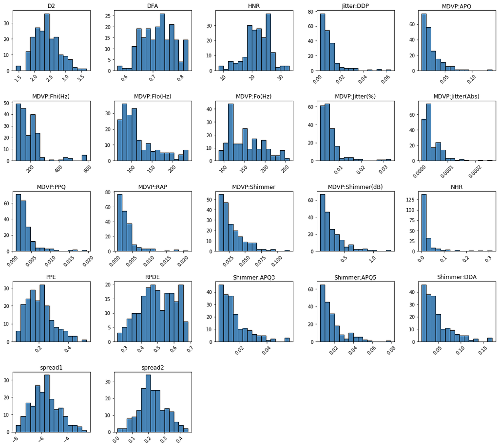

```python
fig = par_df.hist(bins=15,
                 color='steelblue',
                 edgecolor='black', linewidth=1.0,
                 xlabelsize=10, ylabelsize=10,
                 xrot=45, yrot=0,
                 figsize=(10,9),
                 grid=False)

plt.tight_layout(rect=(0, 0, 1.5, 1.5))
```

Multivariate analysis

```python
corr = par_df.corr()
corr
```

|  | MDVP:Fo(Hz) | MDVP:Fhi(Hz) | MDVP:Flo(Hz) | MDVP:Jitter(%) | MDVP:Jitter(Abs) | MDVP:RAP | MDVP:PPQ | Jitter:DDP | MDVP:Shimmer | MDVP:Shimmer(dB) | Shimmer:APQ3 | Shimmer:APQ5 | MDVP:APQ | Shimmer:DDA | NHR | HNR | RPDE | DFA | spread1 | spread2 | D2 | PPE |
| --- | --- | --- | --- | --- | --- | --- | --- | --- | --- | --- | --- | --- | --- | --- | --- | --- | --- | --- | --- | --- | --- | --- |
| MDVP:Fo(Hz) | 1.000000 | 0.400985 | 0.596546 | -0.118003 | -0.382027 | -0.076194 | -0.112165 | -0.076213 | -0.098374 | -0.073742 | -0.094717 | -0.070682 | -0.077774 | -0.094732 | -0.021981 | 0.059144 | -0.383894 | -0.446013 | -0.413738 | -0.249450 | 0.177980 | -0.372356 |
| MDVP:Fhi(Hz) | 0.400985 | 1.000000 | 0.084951 | 0.102086 | -0.029198 | 0.097177 | 0.091126 | 0.097150 | 0.002281 | 0.043465 | -0.003743 | -0.009997 | 0.004937 | -0.003733 | 0.163766 | -0.024893 | -0.112404 | -0.343097 | -0.076658 | -0.002954 | 0.176323 | -0.069543 |
| MDVP:Flo(Hz) | 0.596546 | 0.084951 | 1.000000 | -0.139919 | -0.277815 | -0.100519 | -0.095828 | -0.100488 | -0.144543 | -0.119089 | -0.150747 | -0.101095 | -0.107293 | -0.150737 | -0.108670 | 0.210851 | -0.400143 | -0.050406 | -0.394857 | -0.243829 | -0.100629 | -0.340071 |
| MDVP:Jitter(%) | -0.118003 | 0.102086 | -0.139919 | 1.000000 | 0.935714 | 0.990276 | 0.974256 | 0.990276 | 0.769063 | 0.804289 | 0.746625 | 0.725561 | 0.758255 | 0.746635 | 0.906959 | -0.728165 | 0.360673 | 0.098572 | 0.693577 | 0.385123 | 0.433434 | 0.721543 |
| MDVP:Jitter(Abs) | -0.382027 | -0.029198 | -0.277815 | 0.935714 | 1.000000 | 0.922911 | 0.897778 | 0.922913 | 0.703322 | 0.716601 | 0.697153 | 0.648961 | 0.648793 | 0.697170 | 0.834972 | -0.656810 | 0.441839 | 0.175036 | 0.735779 | 0.388543 | 0.310694 | 0.748162 |
| MDVP:RAP | -0.076194 | 0.097177 | -0.100519 | 0.990276 | 0.922911 | 1.000000 | 0.957317 | 1.000000 | 0.759581 | 0.790652 | 0.744912 | 0.709927 | 0.737455 | 0.744919 | 0.919521 | -0.721543 | 0.342140 | 0.064083 | 0.648328 | 0.324407 | 0.426605 | 0.670999 |
| MDVP:PPQ | -0.112165 | 0.091126 | -0.095828 | 0.974256 | 0.897778 | 0.957317 | 1.000000 | 0.957319 | 0.797826 | 0.839239 | 0.763580 | 0.786780 | 0.804139 | 0.763592 | 0.844604 | -0.731510 | 0.333274 | 0.196301 | 0.716489 | 0.407605 | 0.412524 | 0.769647 |
| Jitter:DDP | -0.076213 | 0.097150 | -0.100488 | 0.990276 | 0.922913 | 1.000000 | 0.957319 | 1.000000 | 0.759555 | 0.790621 | 0.744894 | 0.709907 | 0.737439 | 0.744901 | 0.919548 | -0.721494 | 0.342079 | 0.064026 | 0.648328 | 0.324377 | 0.426556 | 0.671005 |
| MDVP:Shimmer | -0.098374 | 0.002281 | -0.144543 | 0.769063 | 0.703322 | 0.759581 | 0.797826 | 0.759555 | 1.000000 | 0.987258 | 0.987625 | 0.982835 | 0.950083 | 0.987626 | 0.722194 | -0.835271 | 0.447424 | 0.159954 | 0.654734 | 0.452025 | 0.507088 | 0.693771 |
| MDVP:Shimmer(dB) | -0.073742 | 0.043465 | -0.119089 | 0.804289 | 0.716601 | 0.790652 | 0.839239 | 0.790621 | 0.987258 | 1.000000 | 0.963198 | 0.973751 | 0.960977 | 0.963202 | 0.744477 | -0.827805 | 0.410684 | 0.165157 | 0.652547 | 0.454314 | 0.512233 | 0.695058 |
| Shimmer:APQ3 | -0.094717 | -0.003743 | -0.150747 | 0.746625 | 0.697153 | 0.744912 | 0.763580 | 0.744894 | 0.987625 | 0.963198 | 1.000000 | 0.960070 | 0.896645 | 1.000000 | 0.716207 | -0.827123 | 0.435242 | 0.151124 | 0.610967 | 0.402243 | 0.467265 | 0.645377 |
| Shimmer:APQ5 | -0.070682 | -0.009997 | -0.101095 | 0.725561 | 0.648961 | 0.709927 | 0.786780 | 0.709907 | 0.982835 | 0.973751 | 0.960070 | 1.000000 | 0.949146 | 0.960072 | 0.658080 | -0.813753 | 0.399903 | 0.213873 | 0.646809 | 0.457195 | 0.502174 | 0.702456 |
| MDVP:APQ | -0.077774 | 0.004937 | -0.107293 | 0.758255 | 0.648793 | 0.737455 | 0.804139 | 0.737439 | 0.950083 | 0.960977 | 0.896645 | 0.949146 | 1.000000 | 0.896647 | 0.694019 | -0.800407 | 0.451379 | 0.157276 | 0.673158 | 0.502188 | 0.536869 | 0.721694 |
| Shimmer:DDA | -0.094732 | -0.003733 | -0.150737 | 0.746635 | 0.697170 | 0.744919 | 0.763592 | 0.744901 | 0.987626 | 0.963202 | 1.000000 | 0.960072 | 0.896647 | 1.000000 | 0.716215 | -0.827130 | 0.435237 | 0.151132 | 0.610971 | 0.402223 | 0.467261 | 0.645389 |
| NHR | -0.021981 | 0.163766 | -0.108670 | 0.906959 | 0.834972 | 0.919521 | 0.844604 | 0.919548 | 0.722194 | 0.744477 | 0.716207 | 0.658080 | 0.694019 | 0.716215 | 1.000000 | -0.714072 | 0.370890 | -0.131882 | 0.540865 | 0.318099 | 0.470949 | 0.552591 |
| HNR | 0.059144 | -0.024893 | 0.210851 | -0.728165 | -0.656810 | -0.721543 | -0.731510 | -0.721494 | -0.835271 | -0.827805 | -0.827123 | -0.813753 | -0.800407 | -0.827130 | -0.714072 | 1.000000 | -0.598736 | -0.008665 | -0.673210 | -0.431564 | -0.601401 | -0.692876 |
| RPDE | -0.383894 | -0.112404 | -0.400143 | 0.360673 | 0.441839 | 0.342140 | 0.333274 | 0.342079 | 0.447424 | 0.410684 | 0.435242 | 0.399903 | 0.451379 | 0.435237 | 0.370890 | -0.598736 | 1.000000 | -0.110950 | 0.591117 | 0.479905 | 0.236931 | 0.545886 |
| DFA | -0.446013 | -0.343097 | -0.050406 | 0.098572 | 0.175036 | 0.064083 | 0.196301 | 0.064026 | 0.159954 | 0.165157 | 0.151124 | 0.213873 | 0.157276 | 0.151132 | -0.131882 | -0.008665 | -0.110950 | 1.000000 | 0.195668 | 0.166548 | -0.165381 | 0.270445 |
| spread1 | -0.413738 | -0.076658 | -0.394857 | 0.693577 | 0.735779 | 0.648328 | 0.716489 | 0.648328 | 0.654734 | 0.652547 | 0.610967 | 0.646809 | 0.673158 | 0.610971 | 0.540865 | -0.673210 | 0.591117 | 0.195668 | 1.000000 | 0.652358 | 0.495123 | 0.962435 |
| spread2 | -0.249450 | -0.002954 | -0.243829 | 0.385123 | 0.388543 | 0.324407 | 0.407605 | 0.324377 | 0.452025 | 0.454314 | 0.402243 | 0.457195 | 0.502188 | 0.402223 | 0.318099 | -0.431564 | 0.479905 | 0.166548 | 0.652358 | 1.000000 | 0.523532 | 0.644711 |
| D2 | 0.177980 | 0.176323 | -0.100629 | 0.433434 | 0.310694 | 0.426605 | 0.412524 | 0.426556 | 0.507088 | 0.512233 | 0.467265 | 0.502174 | 0.536869 | 0.467261 | 0.470949 | -0.601401 | 0.236931 | -0.165381 | 0.495123 | 0.523532 | 1.000000 | 0.480585 |
| PPE | -0.372356 | -0.069543 | -0.340071 | 0.721543 | 0.748162 | 0.670999 | 0.769647 | 0.671005 | 0.693771 | 0.695058 | 0.645377 | 0.702456 | 0.721694 | 0.645389 | 0.552591 | -0.692876 | 0.545886 | 0.270445 | 0.962435 | 0.644711 | 0.480585 | 1.000000 |

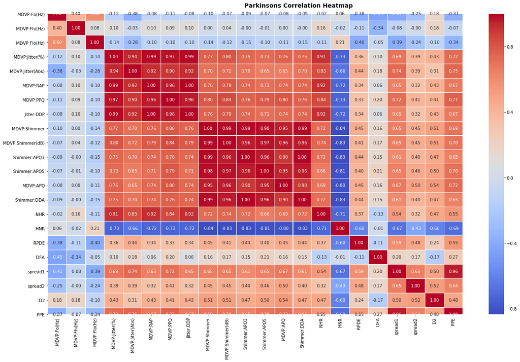

```python
fig, (ax) = plt.subplots(1,1, figsize=(22,12))

hm = sns.heatmap(corr,
                 ax=ax,
                 cmap="coolwarm",
                 annot=True,
                 fmt='.2f',
                 linewidths=.05)

fig.subplots_adjust(top=0.95)
fig.suptitle('Parkinsons Correlation Heatmap',
              fontsize=14,
              fontweight='bold')
```

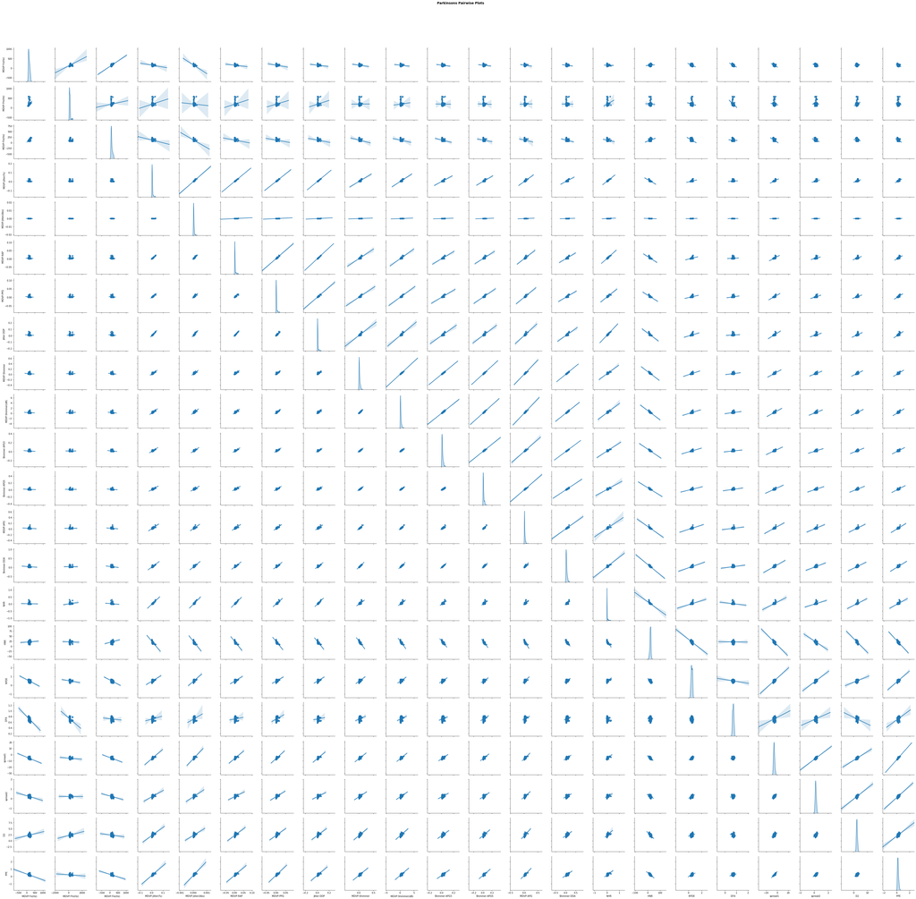

```python
temp = par_df.drop('status', axis=1)
pp = sns.pairplot(temp,
                  diag_kws=dict(shade=True),
                  diag_kind="kde",
                  kind="reg")

fig = pp.fig
fig.subplots_adjust(top=0.93, wspace=0.3)
fig.suptitle('Parkinsons Pairwise Plots', fontsize=14, fontweight='bold')
```

**Inference:**

- From the above analysis we can see that the spread of each column is small. The data for each column is limited to only a small cloud at the center.
- The number of datapoints for status = 1 is much greater than status =0, so the model will be better at predicting parkinsons better

```python
X = par_df.drop(['status', 'name'], axis=1)
y = par_df['status']
```

```python
X_train, X_test, y_train, y_test = train_test_split(X, y, test_size=0.30, random_state=5)
```

```python
dt_model = DecisionTreeClassifier(criterion = 'entropy', random_state=7 )
dt_model.fit(X_train, y_train)
```

```
DecisionTreeClassifier(class_weight=None, criterion='entropy', max_depth=None,
                       max_features=None, max_leaf_nodes=None,
                       min_impurity_decrease=0.0, min_impurity_split=None,
                       min_samples_leaf=1, min_samples_split=2,
                       min_weight_fraction_leaf=0.0, presort=False,
                       random_state=7, splitter='best')
```

```python
print (pd.DataFrame(dt_model.feature_importances_, columns = ["Imp"], index = X_train.columns))
```

```
                       Imp
MDVP:Fo(Hz)       0.166074
MDVP:Fhi(Hz)      0.102057
MDVP:Flo(Hz)      0.000000
MDVP:Jitter(%)    0.000000
MDVP:Jitter(Abs)  0.000000
MDVP:RAP          0.000000
MDVP:PPQ          0.000000
Jitter:DDP        0.000000
MDVP:Shimmer      0.038690
MDVP:Shimmer(dB)  0.000000
Shimmer:APQ3      0.064315
Shimmer:APQ5      0.000000
MDVP:APQ          0.107477
Shimmer:DDA       0.000000
NHR               0.000000
HNR               0.082326
RPDE              0.037366
DFA               0.000000
spread1           0.000000
spread2           0.000000
D2                0.054182
PPE               0.347513
```

From the above data it shows that there are a lot of columns that don't affect the dependent variable

```python
y_pred = dt_model.predict(X_test)
```

```python
print(dt_model.score(X_test,y_test))
print(confusion_matrix(y_test, y_pred))
print(classification_report(y_test, y_pred))
```

```
0.9322033898305084
[[13  3]
 [ 1 42]]
              precision    recall  f1-score   support

           0       0.93      0.81      0.87        16
           1       0.93      0.98      0.95        43

    accuracy                           0.93        59
   macro avg       0.93      0.89      0.91        59
weighted avg       0.93      0.93      0.93        59
```

As expected the model performs better in identifying positive parkinsons cases. Of all the positive values in the test set, it is able to correctly predict 98% of the time and of the times it predicts true, it is correct 93% of the time. For predicting Parkinsons is negavitive, the model performs a bit poor. It is able to correctly predict 93% of the time but it only identified 81% of times as parkinsons as negative.

```python
fpr, tpr, thresholds = roc_curve(y_test, y_pred)
roc_auc = auc(fpr, tpr)
roc_auc
```

```
0.8946220930232558
```

Plotting the ROC curve

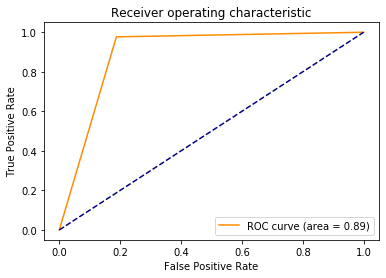

```python
plt.plot(fpr, tpr, color='darkorange', label='ROC curve (area = %0.2f)' % roc_auc)
plt.plot([0, 1], [0, 1], color='navy', linestyle='--')
plt.xlabel('False Positive Rate')
plt.ylabel('True Positive Rate')
plt.title('Receiver operating characteristic')
plt.legend(loc="lower right")
```

Plotting the graphical representation for the decision tree

```python
train_char_labels = ['No','Yes']
from IPython.display import Image
from sklearn import tree
from os import system

par_file = open('C:\AIML_assignments\Residency-4\Assignment-3\par_file.dot','w')
dot_data = tree.export_graphviz(dt_model,out_file=par_file, feature_names=list(X_train), class_names=list(train_char_labels))
par_file.close()
```

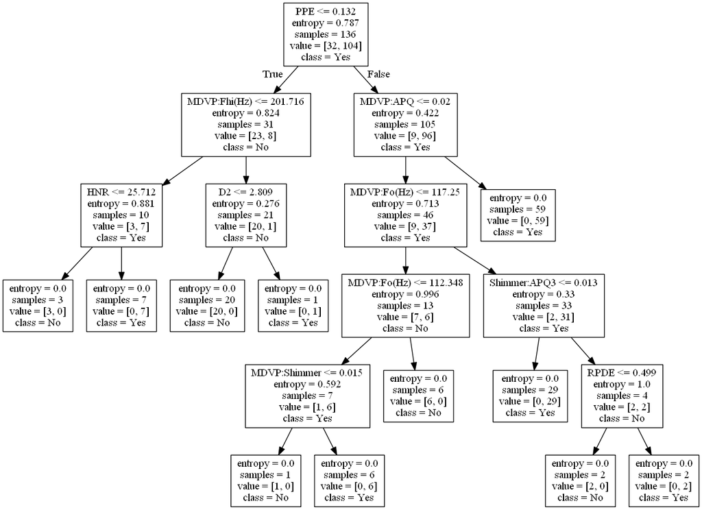

```python
system("dot -Tpng C:\AIML_assignments\Residency-4\Assignment-3\par_file.dot -o C:\AIML_assignments\Residency-4\Assignment-3\par_file.png")
Image('C:\AIML_assignments\Residency-4\Assignment-3\par_file.png')
```

Finding optimum value for max depth

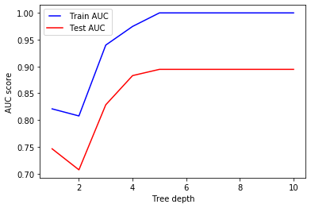

```python
max_depths = np.linspace(1, 10, 10, endpoint=True)
train_results = []
test_results = []
for max_depth in max_depths:
    dt = DecisionTreeClassifier(max_depth=max_depth, criterion = 'entropy', random_state=5)
    dt.fit(X_train, y_train)
    train_pred = dt.predict(X_train)
    fpr, tpr, thresholds = roc_curve(y_train, train_pred)
    roc_auc = auc(fpr,tpr)
    # Add auc score to previous train results
    train_results.append(roc_auc)
    y_pred = dt.predict(X_test)
    fpr, tpr, thresholds = roc_curve(y_test, y_pred)
    roc_auc = auc(fpr,tpr)
    # Add auc score to previous test results
    test_results.append(roc_auc)

from matplotlib.legend_handler import HandlerLine2D
line1, = plt.plot(max_depths, train_results, "b", label= "Train AUC")
line2, = plt.plot(max_depths, test_results, "r", label= "Test AUC")
plt.legend(handler_map={line1: HandlerLine2D(numpoints=2)})
plt.ylabel("AUC score")
plt.xlabel("Tree depth")
plt.show()
```

The optimum value peaks at 5

Finding optimum value for min sample leaf

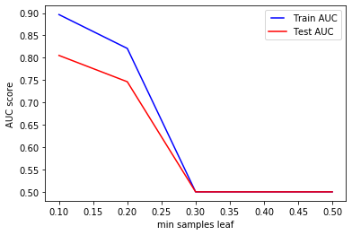

```python
min_samples_leafs = np.linspace(0.1, 0.5, 5, endpoint=True)
train_results = []
test_results = []
for min_samples_leaf in min_samples_leafs:
    dt = DecisionTreeClassifier(min_samples_leaf=min_samples_leaf, criterion="entropy", random_state=5)
    dt.fit(X_train, y_train)
    train_pred = dt.predict(X_train)
    fpr,tpr, thresholds = roc_curve(y_train, train_pred)
    roc_auc = auc(fpr,tpr)
    train_results.append(roc_auc)
    y_pred = dt.predict(X_test)
    fpr,tpr, thresholds = roc_curve(y_test, y_pred)
    roc_auc = auc(fpr, tpr)
    test_results.append(roc_auc)

from matplotlib.legend_handler import HandlerLine2D
line1, = plt.plot(min_samples_leafs, train_results, 'b', label='Train AUC')
line2, = plt.plot(min_samples_leafs, test_results, 'r', label='Test AUC')
plt.legend(handler_map={line1: HandlerLine2D(numpoints=2)})
plt.ylabel('AUC score')
plt.xlabel('min samples leaf')
plt.show()
```

The optimum value is 0.10

Using grid search for both max_depth and min_sample_leaf

```python
max_depths = np.linspace(1, 10, 10, endpoint=True)
min_samples_leafs = np.linspace(0.1, 0.5, 5, endpoint=True)

param_grid = {'max_depth': max_depths, 'min_samples_leaf':min_samples_leafs}
dt_model_reg = DecisionTreeClassifier(criterion='entropy', random_state=5)
```

```python
grid_search = GridSearchCV(estimator = dt_model_reg , param_grid = param_grid, cv = 3, verbose=2, n_jobs = -1)
```

```python
grid_search.fit(X_train,y_train)
```

```
Fitting 3 folds for each of 50 candidates, totalling 150 fits
```

```
[Parallel(n_jobs=-1)]: Using backend LokyBackend with 8 concurrent workers.
[Parallel(n_jobs=-1)]: Done  25 tasks      | elapsed:    2.3s
[Parallel(n_jobs=-1)]: Done 150 out of 150 | elapsed:    2.5s finished
```

```
GridSearchCV(cv=3, error_score='raise-deprecating',
             estimator=DecisionTreeClassifier(class_weight=None,
                                              criterion='entropy',
                                              max_depth=None, max_features=None,
                                              max_leaf_nodes=None,
                                              min_impurity_decrease=0.0,
                                              min_impurity_split=None,
                                              min_samples_leaf=1,
                                              min_samples_split=2,
                                              min_weight_fraction_leaf=0.0,
                                              presort=False, random_state=5,
                                              splitter='best'),
             iid='warn', n_jobs=-1,
             param_grid={'max_depth': array([ 1.,  2.,  3.,  4.,  5.,  6.,  7.,  8.,  9., 10.]),
                         'min_samples_leaf': array([0.1, 0.2, 0.3, 0.4, 0.5])},
             pre_dispatch='2*n_jobs', refit=True, return_train_score=False,
             scoring=None, verbose=2)
```

```python
grid_search.best_params_
```

```
{'max_depth': 2.0, 'min_samples_leaf': 0.2}
```

We'll be using the values obtained from gridsearchcv

Building a regularized decision tree with the inference above

```python
dt_model_reg = DecisionTreeClassifier(criterion='entropy', random_state=5, max_depth=2, min_samples_leaf=0.2)
```

```python
dt_model_reg.fit(X_train, y_train)
```

```
DecisionTreeClassifier(class_weight=None, criterion='entropy', max_depth=2,
                       max_features=None, max_leaf_nodes=None,
                       min_impurity_decrease=0.0, min_impurity_split=None,
                       min_samples_leaf=0.2, min_samples_split=2,
                       min_weight_fraction_leaf=0.0, presort=False,
                       random_state=5, splitter='best')
```

```python
y_pred = dt_model_reg.predict(X_test)
```

```python
print(dt_model_reg.score(X_test,y_test))
print(confusion_matrix(y_test, y_pred))
print(classification_report(y_test, y_pred))
```

```
0.8305084745762712
[[ 9  7]
 [ 3 40]]
              precision    recall  f1-score   support

           0       0.75      0.56      0.64        16
           1       0.85      0.93      0.89        43

    accuracy                           0.83        59
   macro avg       0.80      0.75      0.77        59
weighted avg       0.82      0.83      0.82        59
```

```python
fpr, tpr, thresholds = roc_curve(y_test, y_pred)
roc_auc = auc(fpr, tpr)
roc_auc
```

```
0.7463662790697675
```

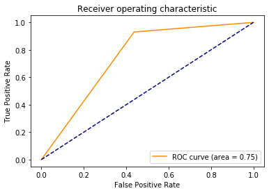

```python
plt.plot(fpr, tpr, color='darkorange', label='ROC curve (area = %0.2f)' % roc_auc)
plt.plot([0, 1], [0, 1], color='navy', linestyle='--')
plt.xlabel('False Positive Rate')
plt.ylabel('True Positive Rate')
plt.title('Receiver operating characteristic')
plt.legend(loc="lower right")
```

After regularlization, the overall and class based accuracy of the model falls significantly. Regularization has made the model perform bad compared to the unregularized one

**Building random forest model**

```python
rfcl = RandomForestClassifier(criterion='entropy',random_state=5)
```

```python
n_estimators = [int(x) for x in np.linspace(start = 5, stop = 500, num =5)]
param_grid = {'n_estimators': n_estimators}
```

```python
rf_grid = GridSearchCV(estimator = rfcl, param_grid = param_grid, cv = 3, verbose=2, n_jobs = -1)
```

```python
rf_grid.fit(X_train,y_train)
```

```
Fitting 3 folds for each of 5 candidates, totalling 15 fits
```

```
[Parallel(n_jobs=-1)]: Using backend LokyBackend with 8 concurrent workers.
[Parallel(n_jobs=-1)]: Done   8 out of  15 | elapsed:    0.5s remaining:    0.4s
[Parallel(n_jobs=-1)]: Done  15 out of  15 | elapsed:    1.3s finished
```

```
GridSearchCV(cv=3, error_score='raise-deprecating',
             estimator=RandomForestClassifier(bootstrap=True, class_weight=None,
                                              criterion='entropy',
                                              max_depth=None,
                                              max_features='auto',
                                              max_leaf_nodes=None,
                                              min_impurity_decrease=0.0,
                                              min_impurity_split=None,
                                              min_samples_leaf=1,
                                              min_samples_split=2,
                                              min_weight_fraction_leaf=0.0,
                                              n_estimators='warn', n_jobs=None,
                                              oob_score=False, random_state=5,
                                              verbose=0, warm_start=False),
             iid='warn', n_jobs=-1,
             param_grid={'n_estimators': [5, 128, 252, 376, 500]},
             pre_dispatch='2*n_jobs', refit=True, return_train_score=False,
             scoring=None, verbose=2)
```

```python
rf_grid.best_params_
```

```
{'n_estimators': 252}
```

Building model with 252 trees

```python
rfcl = RandomForestClassifier(criterion='entropy',random_state=5, n_estimators=252)
```

```python
rfcl.fit(X_train,y_train)
```

```
RandomForestClassifier(bootstrap=True, class_weight=None, criterion='entropy',
                       max_depth=None, max_features='auto', max_leaf_nodes=None,
                       min_impurity_decrease=0.0, min_impurity_split=None,
                       min_samples_leaf=1, min_samples_split=2,
                       min_weight_fraction_leaf=0.0, n_estimators=252,
                       n_jobs=None, oob_score=False, random_state=5, verbose=0,
                       warm_start=False)
```

```python
y_preds = rfcl.predict(X_test)
```

```python
print(rfcl.score(X_test,y_test))
print(confusion_matrix(y_test, y_preds))
print(classification_report(y_test, y_preds))
```

```
0.9152542372881356
[[11  5]
 [ 0 43]]
              precision    recall  f1-score   support

           0       1.00      0.69      0.81        16
           1       0.90      1.00      0.95        43

    accuracy                           0.92        59
   macro avg       0.95      0.84      0.88        59
weighted avg       0.92      0.92      0.91        59
```

Similar to the unregulaized decision trees the model performs better for cases where parkinson is true  
But we can observe that when the model predicts that a case isn't parkinson, it is correct 100% of the time while it is able to predict only 69% of the cases in the test set  
For cases where parkinson is true the model is able to correctly predict all cases(100%) in the test set and when it predicts true, it is correct 90% of the time.